# Tutorial de visualização

Matplotlib-É uma biblioteca python usada para visualização de dados, a qual foi criada para tentar replicar as técnicas de visualização utilizadas no Matlab.

```python
import numpy as np
import pandas as pd
import matplotlib.pyplot as plt
import seaborn as sns
%matplotlib inline
```

Plotando o primeiro gráfico:

primeiro iremos criar uma função qualquer utilizando o numpy para auxiliar.

comandos para criar o gráfico

Um gráfico qualquer-plt.plot(x,y,color=a cor que você quer para o gráfico,label=legenda)

Título - plt.title()

Nomear eixos - plt.xlabe(),plt.ylabel

Legenda-plt.legend()

Plotar o gráfico-plt.show()

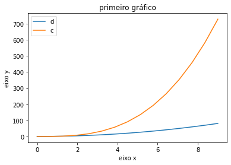

```python
x=np.linspace(0,9,15)
y=x**3
y2=x**2
plt.title('primeiro gráfico')
plt.plot(x,y2,label='d')
plt.plot(x,y,label='c')
plt.legend()
plt.xlabel('eixo x')
plt.ylabel('eixo y')
plt.show()
```

Método para gerar mais de um gráfico ao mesmo tempo

plt.subplots(número de linhas,número de colunas)

[output not shown]

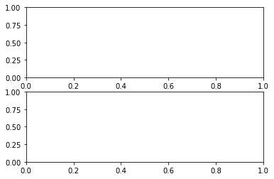

```python
plt.subplots(2,1)
```

Forma de mexer em mais de um gráfico ao mesmo tempo:

mesmo método usados em listas python.(usando as suas posições)

fig,(ax1,ax2) =plt.subplots()

ax1.plot(x,y)

ax1.set_title('titulo')

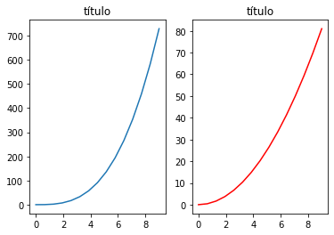

```python
fig,(ax1,ax2)=plt.subplots(1,2)
ax1.plot(x,y)
ax1.set_title('título')
ax2.plot(x,y2,color='r')
ax2.set_title('título')
```

Alterar o tamanho do gráfico:

plt.figure(figsize=(comprimento,largua))

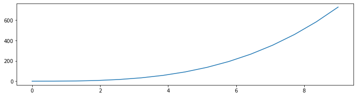

```python
plt.figure(figsize=(12,3))
plt.plot(x,y)
```

Personalizar o gráfico com mais de uma função: fig,ax=subplots()

ax.plot(x, y, color=cor da reta, lw=largura da reta, ls= tipo de traço, marker=marcador, marksize=tamanho do marcador)

possíveis símbolos de marcador: marcador = '+', 'o', '*', 's', ',', '.', '1', '2', '3', '4', ...

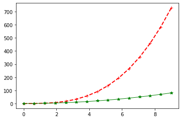

```python
fig,ax=plt.subplots()
ax.plot(x,y,color='red',ls='--',lw=2,marker='+')
ax.plot(x,y2,color='green',ls='-',lw=1,marker='*')
```

# Gráficos especiais

Para plotar esses gráficos irei usar o dataset titanic

```python
df=pd.read_csv('titanic_train.csv')
```

```python
df
```

|  | PassengerId | Survived | Pclass | Name | Sex | Age | SibSp | Parch | Ticket | Fare | Cabin | Embarked |
| --- | --- | --- | --- | --- | --- | --- | --- | --- | --- | --- | --- | --- |
| 0 | 1 | 0 | 3 | Braund, Mr. Owen Harris | male | 22.0 | 1 | 0 | A/5 21171 | 7.2500 | NaN | S |
| 1 | 2 | 1 | 1 | Cumings, Mrs. John Bradley (Florence Briggs Th... | female | 38.0 | 1 | 0 | PC 17599 | 71.2833 | C85 | C |
| 2 | 3 | 1 | 3 | Heikkinen, Miss. Laina | female | 26.0 | 0 | 0 | STON/O2. 3101282 | 7.9250 | NaN | S |
| 3 | 4 | 1 | 1 | Futrelle, Mrs. Jacques Heath (Lily May Peel) | female | 35.0 | 1 | 0 | 113803 | 53.1000 | C123 | S |
| 4 | 5 | 0 | 3 | Allen, Mr. William Henry | male | 35.0 | 0 | 0 | 373450 | 8.0500 | NaN | S |
| ... | ... | ... | ... | ... | ... | ... | ... | ... | ... | ... | ... | ... |
| 886 | 887 | 0 | 2 | Montvila, Rev. Juozas | male | 27.0 | 0 | 0 | 211536 | 13.0000 | NaN | S |
| 887 | 888 | 1 | 1 | Graham, Miss. Margaret Edith | female | 19.0 | 0 | 0 | 112053 | 30.0000 | B42 | S |
| 888 | 889 | 0 | 3 | Johnston, Miss. Catherine Helen "Carrie" | female | NaN | 1 | 2 | W./C. 6607 | 23.4500 | NaN | S |
| 889 | 890 | 1 | 1 | Behr, Mr. Karl Howell | male | 26.0 | 0 | 0 | 111369 | 30.0000 | C148 | C |
| 890 | 891 | 0 | 3 | Dooley, Mr. Patrick | male | 32.0 | 0 | 0 | 370376 | 7.7500 | NaN | Q |

891 rows × 12 columns

# Histograma

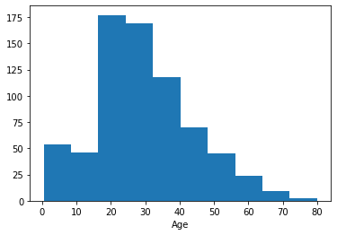

```python
plt.hist(x=df['Age'])
plt.xlabel('Age')
plt.show()
```

# Seaborn

Seaborn - É outra biblioteca python de visualização,a qual constrói em cima do Matplotlib e introduz tipos de plotagens adicionais.

# Boxplot

Boxplot - é uma ferramenta gráfica para representar a variação de dados observados de uma variável numérica por meio de quartis.

plotando um boxplot:

sns.boxplot(x='dados categórico,y='dados númericos',data=Dataframe)

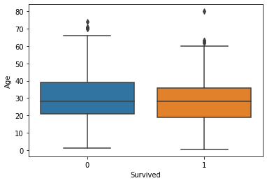

```python
sns.boxplot(x='Survived',y='Age',data=df)
```

# Lmplot

Lmplot-É usado para exibir modelos lineares

Plotar lmplot:

sns.lmplot(x=dados númericos,y=dados númericos,data=dataframe,hue =dados categóricos)

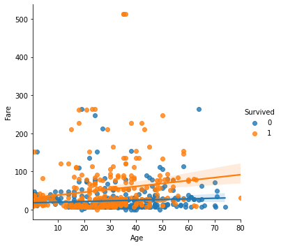

```python
sns.lmplot(x='Age',y='Fare',data=df,hue='Survived')
```

# Scatterplot

Gráficos de Dispersão são representações de dados de duas ou mais variáveis que são organizadas em um gráfico.

sns.scatterplot(x=dados númericos,y=dados númericos,data=Dataframe

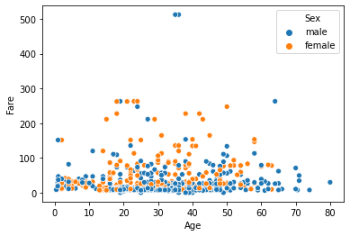

```python
sns.scatterplot(x='Age',y='Fare',data=df,hue='Sex')
```

# Countplot

Countplot - E um gráfico simples mas muito útil, é usado para contar as variáveis

sns.countplot(x=variável escolhida,data)

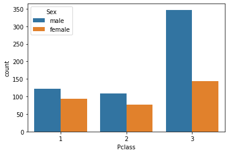

```python
sns.countplot(x='Pclass',data=df,hue='Sex')
```

# Distplot

Distplot - Também é utilizado para fazer histogramas

sns.distplot(variável,kde-aprocimação de distribuição,bins=parâmetros de curva)

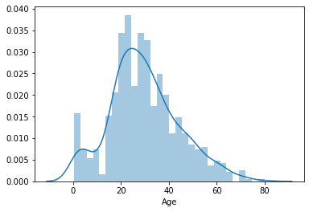

```python
sns.distplot(df['Age'],kde=True,bins=30)
```

# jointplot

jointplot - cria uma curva de distribuição com duas variáveis ao mesmo tempo

sns.jointplot(x=variável,y=variável,data=DataFrame,kind=tipo de distribuição)

tipos de distribuilção=“scatter”,“reg”,“resid”,“kde”,“hex”

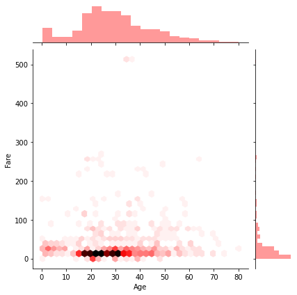

```python
sns.jointplot(x='Age',y='Fare',data=df,kind='hex',color='red')
```

# Pairplot

Pairplot - irá traçar distribuições entre pares em todo o DataFrame (para as colunas numéricas) e suporta um argumento de matiz de cor (para colunas categóricas).

sns.pairplot(data=dataset)

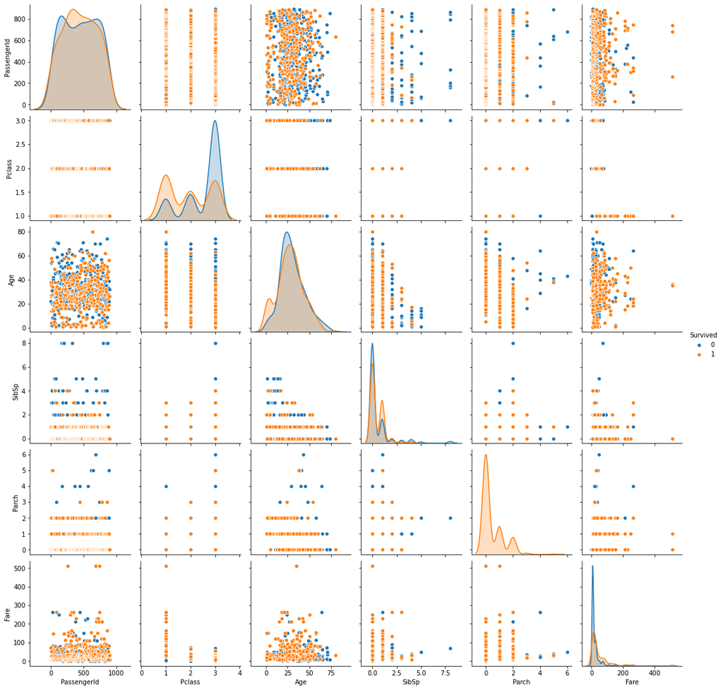

```python
sns.pairplot(data=df,hue='Survived')
```

# Barplot

Barplot - é um gráfico geral que permite que você agregue os dados categóricos baseados em alguma função, por padrão, a média:

sns.barplot(x=variável categórica,y=variável númerica,data=dataframe)

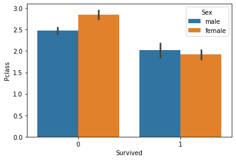

```python
sns.barplot(x='Survived',y='Pclass',data=df,hue='Sex')
```

# Heatmap

Heatmap - Um mapa de calor é uma técnica de visualização de dados que mostra a magnitude de um fenômeno como cor em duas dimensões.

sns.heatmap(data=df)

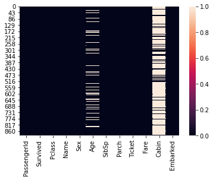

```python
# Esse exemplo mostra os dados faltantes no dataset
sns.heatmap(df.isnull())
```